# Detecting foodborne outbreaks

25 November 2016

## RadioNZ headlines from 13-15 August 2016

- Person dies after gastro outbreak in Hawke's Bay
- Two in critical condition after gastric illness outbreak
- Animal faeces in water supply may be cause of gastro outbreak
- All schools in Havelock North to be closed for next two days as gastro crisis worsens
- Hastings District Council under fire for response to gastro bug
- Mounting anger among Havelock North locals
- Mayor apologises over 'horrific' gastro crisis
- Bug leaves Havelock North a 'ghost town', residents say
- Campylobacter 'same as labour', mother says
- Elderly hard hit by gastroenteritis bug

## Hawke's Bay campylobacteriosis cases

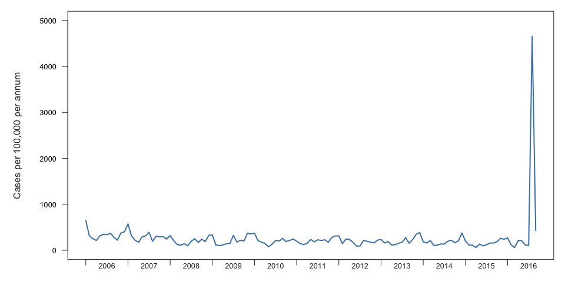

## Google trends for New Zealand

[figure not shown]

## Campylobacteriosis

- *Campylobacter* 'twisted bacteria'
- Predominantly food-borne.
- NZ's most notified disease.
- 6231 cases in 2015, mostly sporadic.
- **A proportion of cases are due to a common source of infection.**

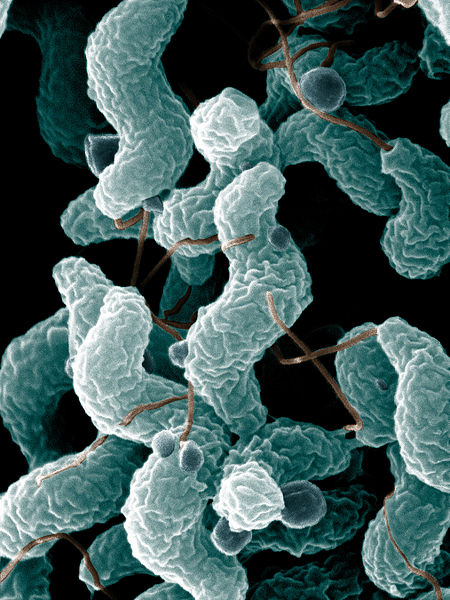

## Manawatu sentinel surveillance site

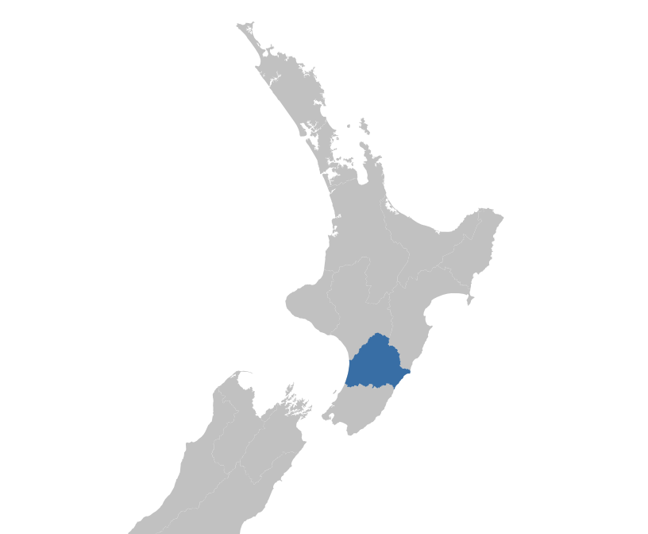

## Manawatu campylobacteriosis cases

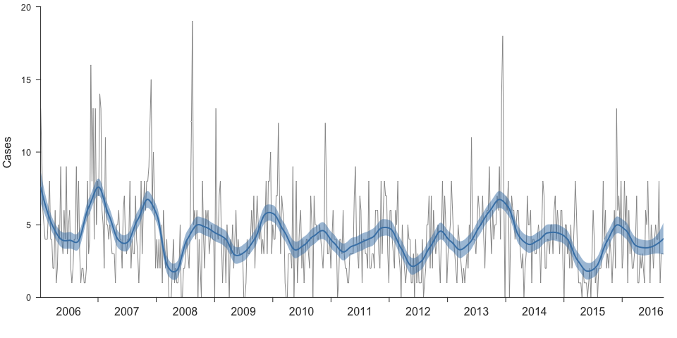

## Manawatu cases before 2008

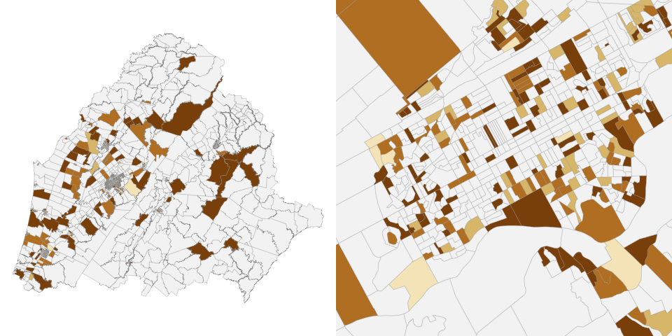

## Manawatu cases after 2008

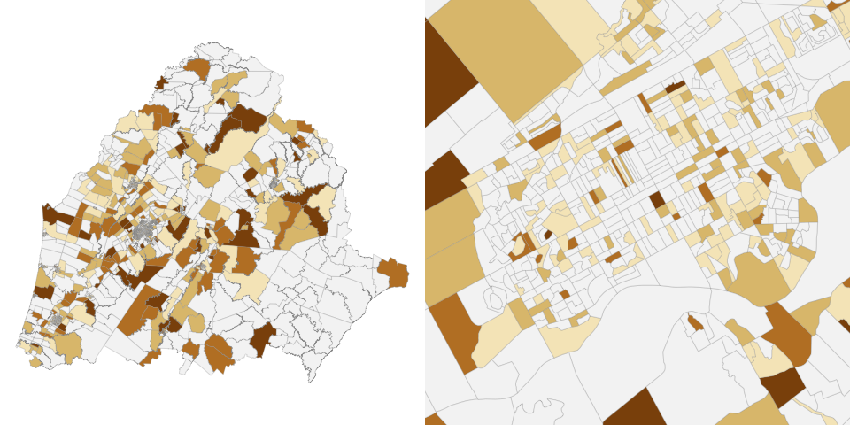

## Model

\[ \begin{aligned} Y_{it} &= \mathsf{Poisson}(n_{it}\lambda_{it})\\ \log{\lambda_{it}} &= R_t + U_{ip[t]} + W_{it} \end{aligned} \]

## Temporal trend

\[ R_t \sim \mathsf{Normal}(2R_{t-1} + R_{t-2}, \tau_R) \]

[video not shown]

## Spatial trend

[video not shown]

## Outbreak detection

\[ \begin{aligned} W_{it} &= \beta_{r[i]} X_{r[i]t}\\ X_{jt} & \underset{iid}\sim \mathsf{Bernoulli}(p)\\ \end{aligned} \]

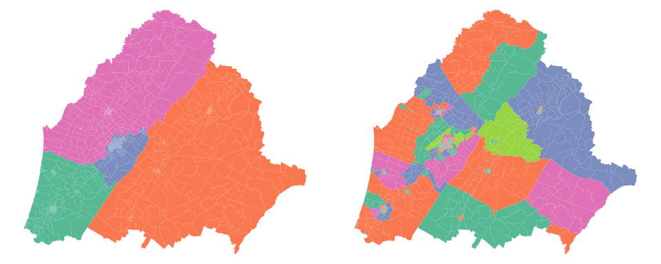

## Priors

\[ \begin{aligned} \tau_R &\sim \mathsf{Gamma}(5,0.01) & p &\sim \mathsf{Beta}(1,51)\\ \tau_U &\sim \mathsf{Gamma}(1,0.5) & \beta_{j} &\underset{iid}\sim \mathsf{Gamma}(1, 1)\\ \end{aligned} \]

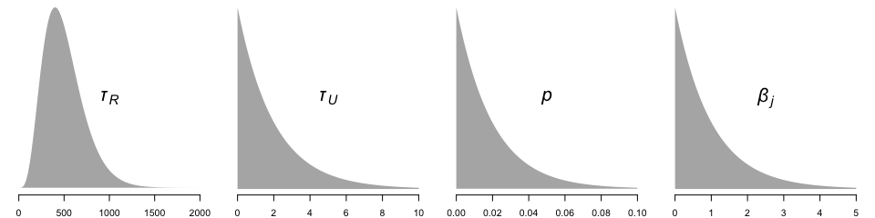

## Block updating MCMC scheme

\[ R \sim \mathsf{Normal}(0, K^{-1}) \]

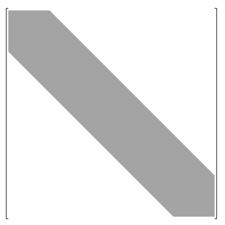

## Block updating MCMC scheme

\[ R_{[~~~\style{color:#4682b4}{\blacksquare}~~~]} \mid R_{[\style{color:#a3c1da}{\blacksquare}~~~\style{color:#a3c1da}{\blacksquare}]} \sim \mathsf{Normal}(-\style{color:#4682b4}{\blacksquare}^{-1}[\style{color:#a3c1da}{\blacksquare}~0~ \style{color:#a3c1da}{\blacksquare}] R, \style{color:#4682b4}{\blacksquare}^{-1}) \]

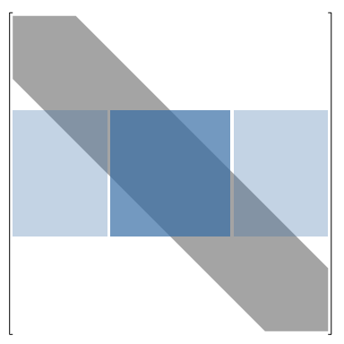

## Results: Trend through time

[video not shown]

## Results: Trend through space

[video not shown]

## Results: Trend through space

[video not shown]

## Results: Outbreaks

[video not shown]

## Summary

- Model smooth trends in space and time.
- Identify potential outbreaks over and above the trends.
- Seems to be a reduction in urban cases pre/post 2008.
- Outbreak detection dependent on how localised cases are and whether outbreak regions match.
- It helps if outbreak regions align with epidemiology.

## Acknowledgements

- **MidCentral Public Health Services**: Tui Shadbolt,  
  Adie Transom
- **mEpiLab**: Rukhshana Akhter, Julie Collins-Emerson,  
  Ahmed Fayaz, Anne Midwinter, Antoine Nohra, Lynn Rogers
- **Ministry for Primary Industries**: Peter van der Logt
- Simon Spencer
- Nigel French

Slides: http://jmarshallnz.github.io/talks/nzsa2016.html

Twitter: [@jmarshallnz](https://twitter.com/jmarshallnz)

Github: jmarshallnz

**Thanks for listening!**

[figure not shown]